# Guía de uso App Science Journal

Edimer David Jaramillo

Marzo de 2019

# Lectura de datos

- Luego de tomar las mediciones y enviarlas a su correo o almacenarlas directamente desde el celular a su computador, es necesario importar dichos registros a R.

```r
# Lectura de datos luz
df_luz <- read.csv(file = "Prueba 1 Grabaci_n 1.csv")

# Lectura de datos sonido
df_sonido <- read.csv(file = "Experimento sin t_tulo Grabaci_n 1.csv")
```

# Edición de nombres de variables

- **Opcional:** por facilidad de manejo se editan los nombres de las variables.

```r
# Editando nombres de luz
names(df_luz) <- c("Tiempo", "Luz")

# Editando nombres de sonido
names(df_sonido) <- c("Tiempo", "Sonido")
```

```r
# Primeros 10 datos de luz
head(df_luz, n = 10)
```

```
##         Tiempo Luz
## 1  1.55068e+12  92
## 2  1.55068e+12  92
## 3  1.55068e+12  92
## 4  1.55068e+12  92
## 5  1.55068e+12  92
## 6  1.55068e+12  92
## 7  1.55068e+12  92
## 8  1.55068e+12  92
## 9  1.55068e+12  92
## 10 1.55068e+12  92
```

```r
# Primeros 10 datos de sonido
head(df_sonido, n = 10)
```

```
##         Tiempo   Sonido
## 1  1.55068e+12 37.78540
## 2  1.55068e+12 35.88001
## 3  1.55068e+12 34.93326
## 4  1.55068e+12 39.93568
## 5  1.55068e+12 38.63764
## 6  1.55068e+12 37.45524
## 7  1.55068e+12 34.65991
## 8  1.55068e+12 34.04971
## 9  1.55068e+12 35.73324
## 10 1.55068e+12 39.71950
```

```r
# Estructura interna de datos sonido
str(df_sonido)
```

```
## 'data.frame':    343 obs. of  2 variables:
##  $ Tiempo: num  1.55e+12 1.55e+12 1.55e+12 1.55e+12 1.55e+12 ...
##  $ Sonido: num  37.8 35.9 34.9 39.9 38.6 ...
```

# Conversión a formato fecha

- La primera variable de las bases de datos obtenidas con *Science Journal* indica el tiempo o momento de medición en milisegundos.
- En R es posible convertir dicha variable que está en formato numérico a formato fecha con la función `as.POSIXct()`.

```r
# Conversión a formato fecha
df_sonido$Tiempo <- as.POSIXct(df_sonido$Tiempo/1000, origin = "1970-01-01")

# Estructura interna
str(df_sonido)
```

```
## 'data.frame':    343 obs. of  2 variables:
##  $ Tiempo: POSIXct, format: "2019-02-20 11:21:38" "2019-02-20 11:21:38" ...
##  $ Sonido: num  37.8 35.9 34.9 39.9 38.6 ...
```

# Gráfico de series temporales

## Con `graphics`

- **Gráfico 1: puntos:**

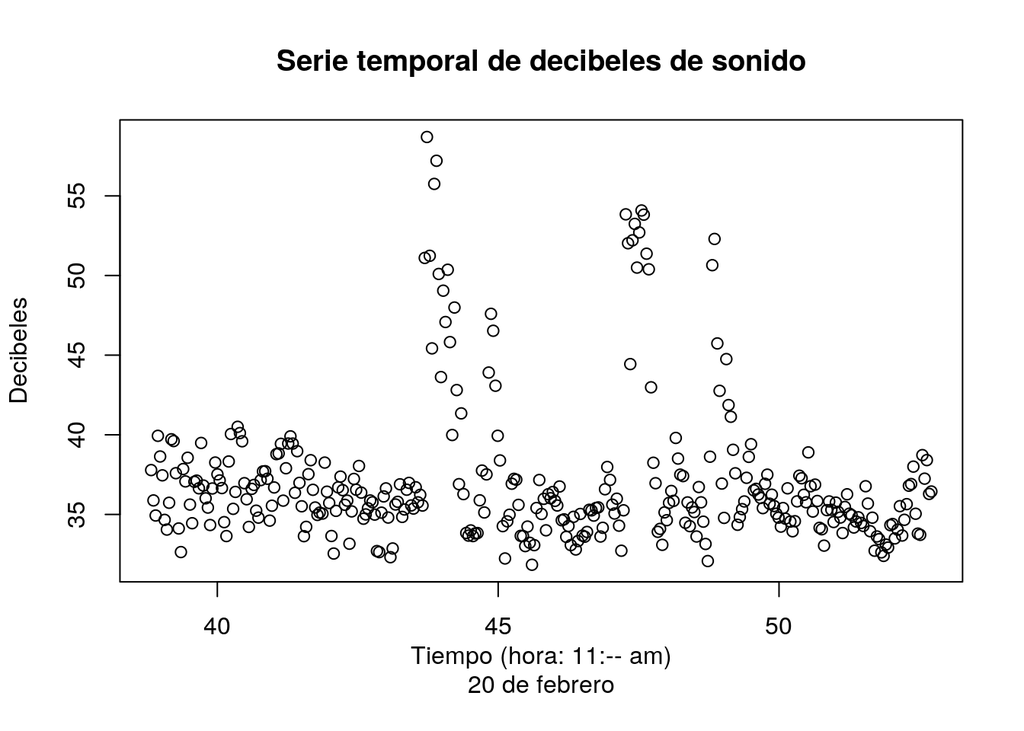

```r
plot(x = df_sonido$Tiempo, y = df_sonido$Sonido,
     xlab = "Tiempo (hora: 11:-- am)\n20 de febrero",
     ylab = "Decibeles",
     main = "Serie temporal de decibeles de sonido")
```

- **Gráfico 2: líneas:**

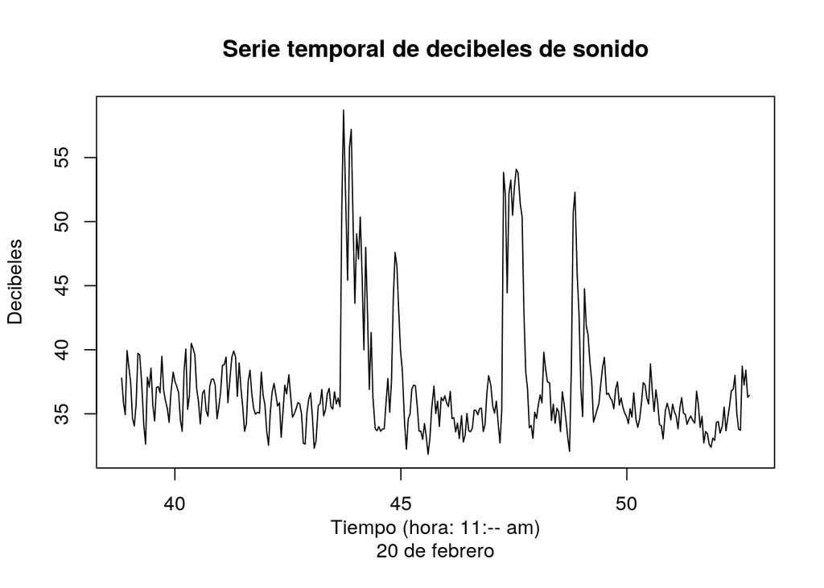

```r
plot(x = df_sonido$Tiempo, y = df_sonido$Sonido, type = "l",
     xlab = "Tiempo (hora: 11:-- am)\n20 de febrero",
     ylab = "Decibeles",
     main = "Serie temporal de decibeles de sonido")
```

- **Gráfico 3: líneas y puntos:**

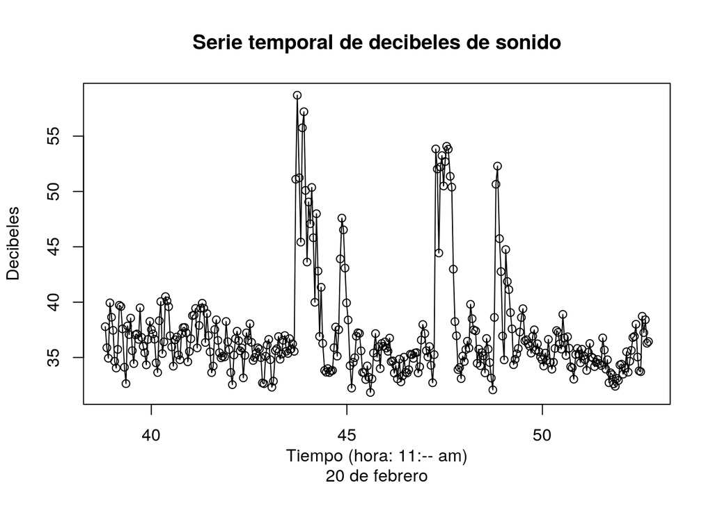

```r
plot(x = df_sonido$Tiempo, y = df_sonido$Sonido, type = "o",
     xlab = "Tiempo (hora: 11:-- am)\n20 de febrero",
     ylab = "Decibeles",
     main = "Serie temporal de decibeles de sonido")
```

## Con `ggplot2`

```r
# Instalar y cargar biblioteca ggplot2
library(ggplot2)
```

- **Gráfico 1: puntos:**

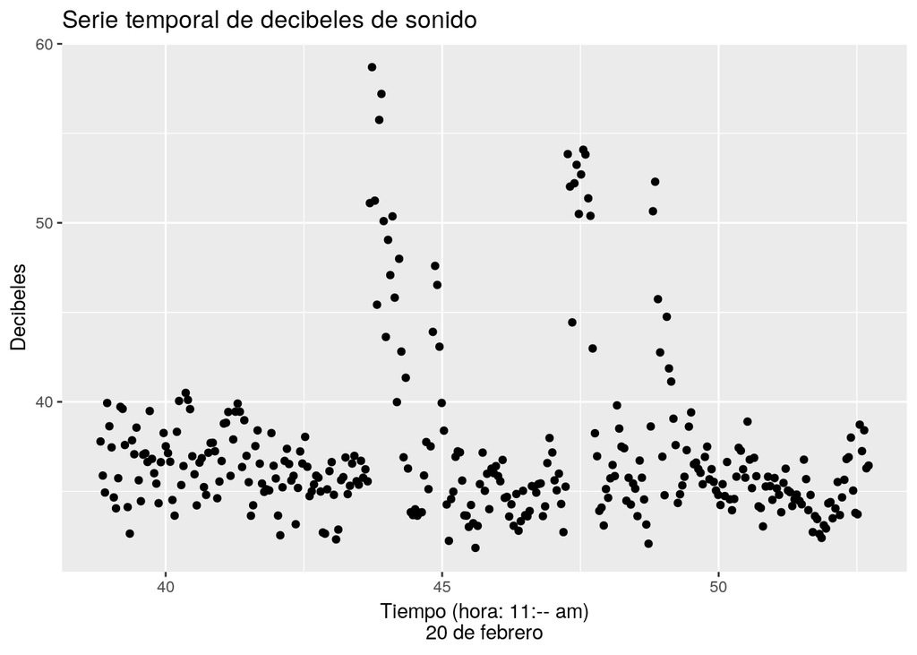

```r
ggplot(data = df_sonido, mapping = aes(x = Tiempo, y = Sonido)) +
  geom_point() +
  labs(x = "Tiempo (hora: 11:-- am)\n20 de febrero", y = "Decibeles",
       title = "Serie temporal de decibeles de sonido")
```

- **Gráfico 2: líneas:**

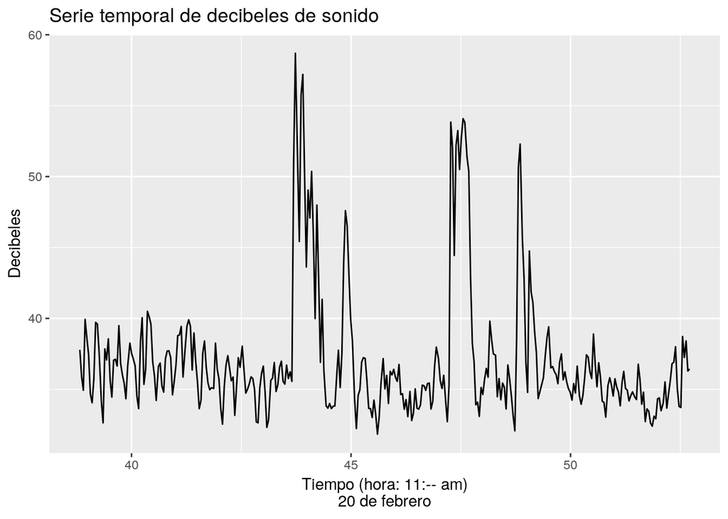

```r
ggplot(data = df_sonido, mapping = aes(x = Tiempo, y = Sonido)) +
  geom_line() +
  labs(x = "Tiempo (hora: 11:-- am)\n20 de febrero", y = "Decibeles",
       title = "Serie temporal de decibeles de sonido")
```

- **Gráfico 3: líneas y puntos:**

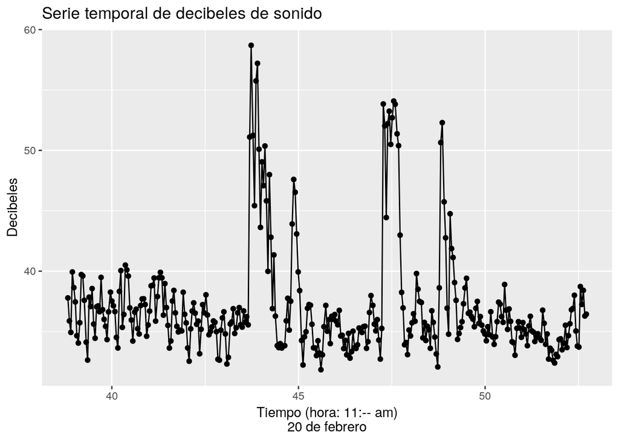

```r
ggplot(data = df_sonido, mapping = aes(x = Tiempo, y = Sonido)) +
  geom_point() +
  geom_line() +
  labs(x = "Tiempo (hora: 11:-- am)\n20 de febrero", y = "Decibeles",
       title = "Serie temporal de decibeles de sonido")
```

# Distribución del sonido (decibeles)

## Con `graphics`

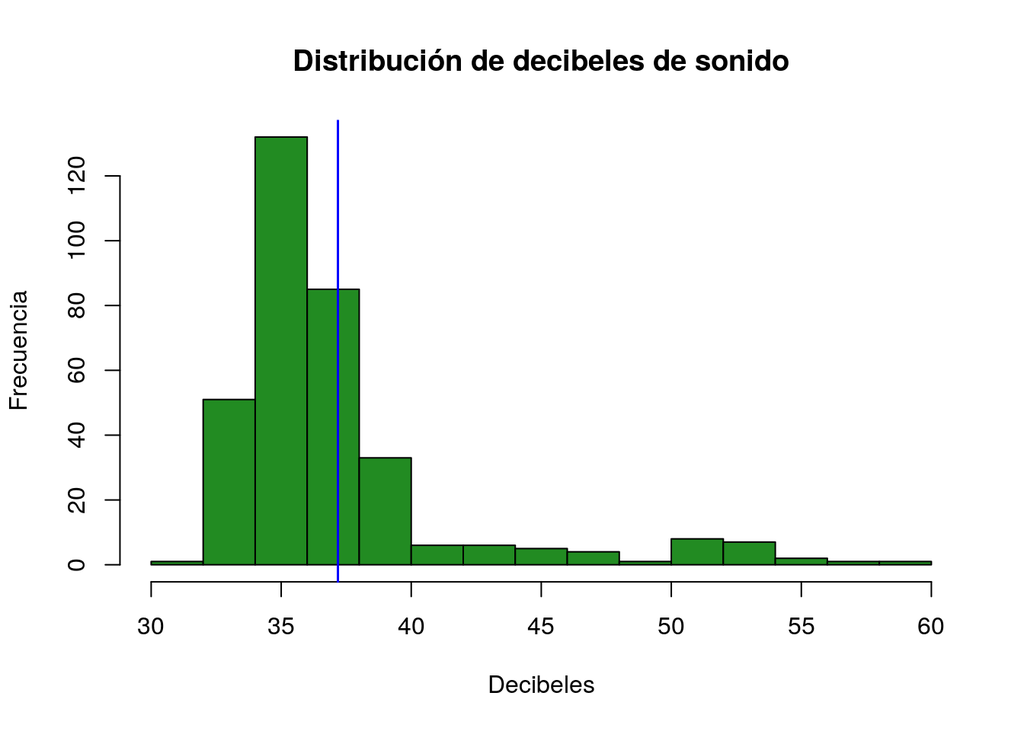

```r
hist(df_sonido$Sonido, xlab = "Decibeles",
     ylab = "Frecuencia", main = "Distribución de decibeles de sonido",
     col = "forestgreen")
abline(v = mean(df_sonido$Sonido), lwd = 1.5, col = "blue")
```

## Con `ggplot2`

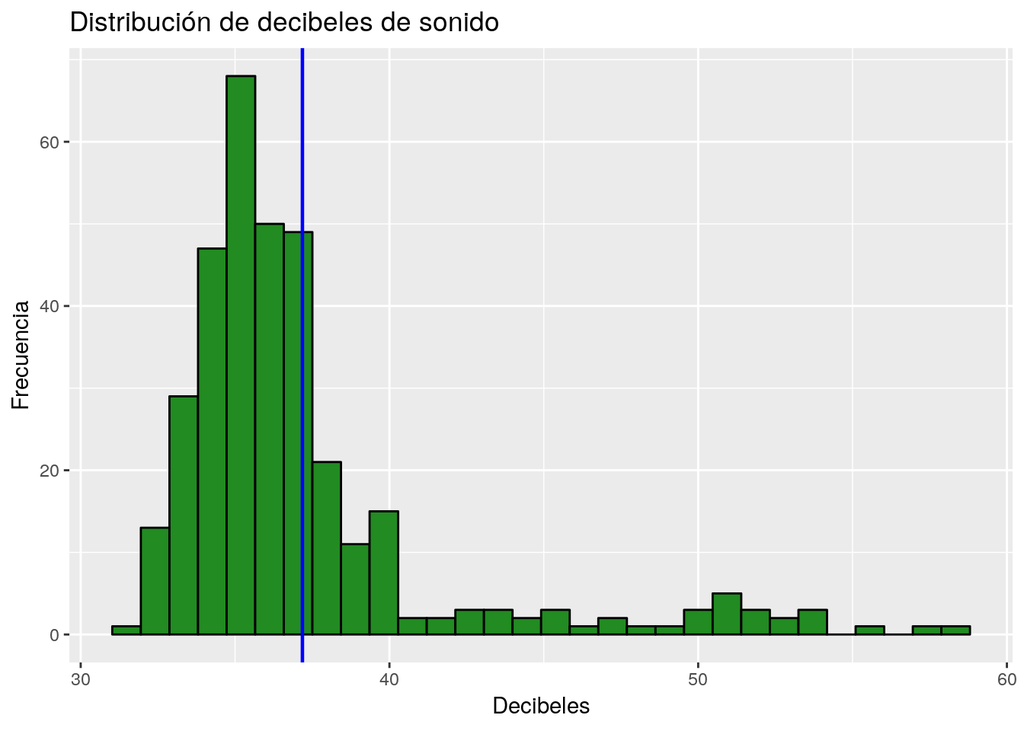

```r
ggplot(data = df_sonido, mapping = aes(x = Sonido)) +
  geom_histogram(fill = "forestgreen", color = "black") +
  geom_vline(xintercept = mean(df_sonido$Sonido), lwd = 0.8, color = "blue") +
  labs(x = "Decibeles", y = "Frecuencia",
       title = "Distribución de decibeles de sonido")
```

# Resumen de datos temporales

- **Promedio de decibeles de sonido:**

```r
mean(df_sonido$Sonido)
```

```
## [1] 37.18139
```

- **Desviación estándar de decibeles de sonido:**

```r
sd(df_sonido$Sonido)
```

```
## [1] 4.667552
```

- **Mediana de decibeles de sonido:**

```r
median(df_sonido$Sonido)
```

```
## [1] 35.81795
```

- **Mínimo de decibeles de sonido:**

```r
min(df_sonido$Sonido)
```

```
## [1] 31.84132
```

- **Máximo de decibeles de sonido:**

```r
max(df_sonido$Sonido)
```

```
## [1] 58.69666
```

- **Cuartil 3 (percentil 75 - decil 7.5) de decibeles de sonido:**

```r
quantile(df_sonido$Sonido, probs = 0.75)
```

```
##      75%
## 37.50652
```

- **Percentil 98 de decibeles de sonido:**

```r
quantile(df_sonido$Sonido, probs = 0.98)
```

```
##     98%
## 52.7892
```

- **Resumen general de decibeles de sonido:**

```r
summary(df_sonido$Sonido)
```

```
##    Min. 1st Qu.  Median    Mean 3rd Qu.    Max.
##   31.84   34.64   35.82   37.18   37.51   58.70
```

# Ejemplo de base de datos

- Suponga lo siguiente:
  - Se va a comparar el nivel de sonido en horas de la mañana vs horas de la tarde.
  - Las mediciones se harán de lunes a viernes durante 3 semanas.
  - Cada día se tomarán tres medidas en la mañana y tres medidas en la tarde.
  - Se tendrán como variables respuesta el promedio y el percentil 98 de decibeles de sonido.

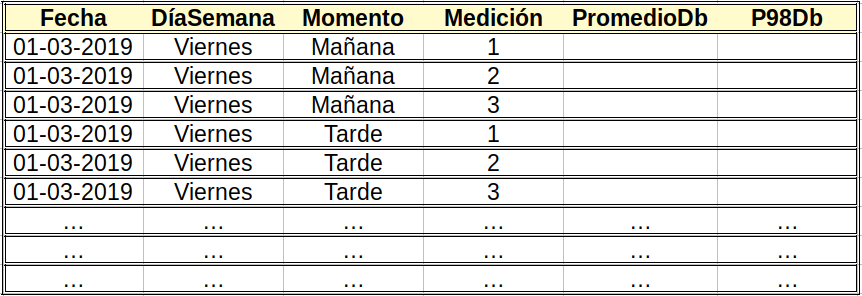